# Practical Machine Learning

# Prediction Assignment Writeup

## Executive Summary

Using devices such as Jawbone Up, Nike FuelBand, and Fitbit it is now possible to collect a large amount of data about personal activity relatively inexpensively. One thing that people regularly do is quantify how much of a particular activity they do, but they rarely quantify how well they do it. The data for this assignment come from this source: http://groupware.les.inf.puc-rio.br/har.

The outcome variable is the ‘classe’ factor variable that has 5 possible values:

- exactly according to the specification (Class A)
- throwing the elbows to the front (Class B)
- lifting the dumbbell only halfway (Class C)
- lowering the dumbbell only halfway (Class D)
- throwing the hips to the front (Class E).

Our goal is to use data from accelerometers on the belt, forearm, arm, and dumbell of 6 participants to predict the manner in which they did the exercise.

## Data Acquisition and Analysis

The training data for this project are available here: https://d396qusza40orc.cloudfront.net/predmachlearn/pml-training.csv

The test data are available here: https://d396qusza40orc.cloudfront.net/predmachlearn/pml-testing.csv

First we’ll load the required libraries and fetch the data from the testing and training datasets.

```r
suppressWarnings(library( caret))
suppressWarnings(library( randomForest))
```

```r
suppressWarnings(library( corrplot))
suppressWarnings(library( rattle))
trainingURL <- "https://d396qusza40orc.cloudfront.net/predmachlearn/pml-training.csv"
trainingFile<- "pml-training.csv"
testingURL <- "https://d396qusza40orc.cloudfront.net/predmachlearn/pml-testing.csv"
testingFile<- "pml-testing.csv"
setInternet2(use=TRUE)
download.file(trainingURL, trainingFile)
download.file(testingURL, testingFile)
training <- read.csv( trainingFile,  na.strings=c("NA","#DIV/0!", ""))
testing <- read.csv( testingFile,  na.strings=c("NA","#DIV/0!", ""))

dim( training)
```

```
## [1] 19622   160
```

```r
dim(testing)
```

```
## [1]  20 160
```

On reviewing the training data with `str()` we see that several variables are NA or with very little variance.

Next we’ll clean the data to discard columns with NA values and near-zero variance data. We’ll also discard the id column (so it does not interfere with the learning alogorithms), and columns that are not relevant to the study.

```r
training<- training[,colSums(is.na(training)) == 0]
nearZero <- nearZeroVar( training)
training <- training[, -nearZero]
discardCols<-grep("X|user_name|raw_timestamp_part_1|raw_timestamp_part_2|cvtd_timestamp|num_window", names(training))
training<- training[, -discardCols]

testing<- testing[,colSums(is.na(testing)) == 0]
nearZero <- nearZeroVar( testing)
testing <- testing[, -nearZero]
discardCols<-grep("X|user_name|raw_timestamp_part_1|raw_timestamp_part_2|cvtd_timestamp|num_window", names(testing))
testing<- testing[, -discardCols]

dim(training)
```

```
## [1] 19622    53
```

```r
dim(testing)
```

```
## [1] 20 53
```

Our updated training dataset now contains the variables we need for analysis. The testing dataset has also been pared down to the same set of variables- this will allow us to apply our machine learning algorithm built using the training dataset to the testing dataset.

In order to perform a crossvalidation, we’ll split the training dataset into two subsets- 70% data for the actual training, and 30% data for the crossvaldation.

```r
inTrain<- createDataPartition( y=training$classe, p=0.7, list=FALSE)
trainSet<- training[inTrain,]
xvalidSet<- training[-inTrain,]
```

Our training `(trainSet)` and cross-validation `(xvalidSet)` datasets now have 53 columns, with the `classe` column as the last column. We’ll exclude the 53rd column from our analysis since this is the variable we’re trying to predict.

Let’s review the correlations between the variables. we’ll set `order="FPC"` for the first principal component order.

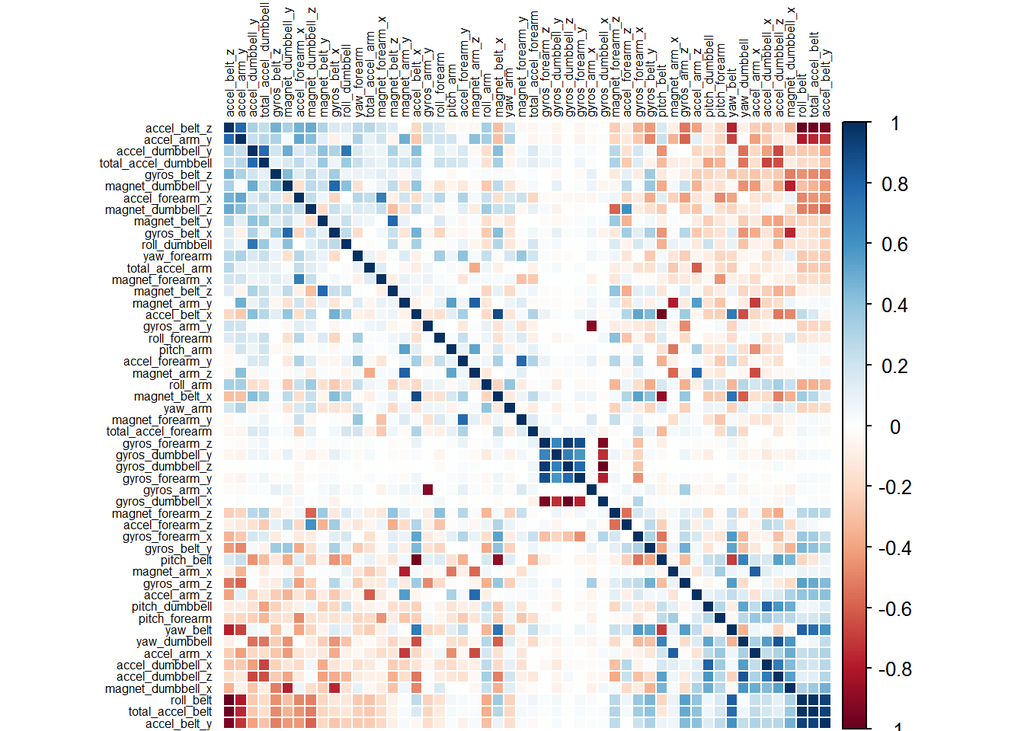

```r
trainCor<- cor( trainSet[,-53])
corrplot(trainCor, order="FPC", method="color", tl.col = "black", tl.cex = 0.5)
```

The blue color indicates the positive correlation, red color indicates negative correlation. The darker the shade, the stronger the correlation.

## Principle Component Analysis

For analysis, we’ll set the seed to enable reproducibility. And we’ll preprocess the training dataset using principle component analysis, and create a prediction based on the preprocessing. We’ll also apply the same pca to the crossvalidation dataset.

```r
set.seed( 1234)
preObj<- preProcess( trainSet[,-53], method="pca", thresh=0.99)
trainPred<- predict( preObj, trainSet[,-53])
xvalidPred<- predict( preObj, xvalidSet[,-53])
```

Next we’ll train a random forest model with the `trainControl` method set for crossvalidation.

```r
trainFit<- train( trainSet$classe ~., method="rf", data=trainPred, trControl = trainControl(method = "cv", number = 5), importance=TRUE)
trainFit
```

```
## Random Forest
##
## 13737 samples
##    35 predictor
##     5 classes: 'A', 'B', 'C', 'D', 'E'
##
## No pre-processing
## Resampling: Cross-Validated (5 fold)
##
## Summary of sample sizes: 10987, 10990, 10990, 10990, 10991
##
## Resampling results across tuning parameters:
##
##   mtry  Accuracy   Kappa      Accuracy SD  Kappa SD
##    2    0.9724116  0.9650834  0.004780236  0.006049299
##   19    0.9654228  0.9562452  0.005614796  0.007095261
##   36    0.9583612  0.9473097  0.005409830  0.006834732
##
## Accuracy was used to select the optimal model using  the largest value.
## The final value used for the model was mtry = 2.
```

We’ll generate the confusionMatrix using the crossvaliation dataset to review the accuracy of the model generated with the training dataset.

```r
confMat<- confusionMatrix( xvalidSet$classe, predict(trainFit, xvalidPred))
confMat
```

```
## Confusion Matrix and Statistics
##
##           Reference
## Prediction    A    B    C    D    E
##          A 1667    3    4    0    0
##          B   29 1104    5    0    1
##          C    2   11 1008    5    0
##          D    0    0   37  922    5
##          E    0    2    9    1 1070
##
## Overall Statistics
##
##                Accuracy : 0.9806
##                  95% CI : (0.9768, 0.984)
##     No Information Rate : 0.2885
##     P-Value [Acc > NIR] : < 2.2e-16
##
##                   Kappa : 0.9755
##  Mcnemar's Test P-Value : NA
##
## Statistics by Class:
##
##                      Class: A Class: B Class: C Class: D Class: E
## Sensitivity            0.9817   0.9857   0.9483   0.9935   0.9944
## Specificity            0.9983   0.9927   0.9963   0.9915   0.9975
## Pos Pred Value         0.9958   0.9693   0.9825   0.9564   0.9889
## Neg Pred Value         0.9926   0.9966   0.9887   0.9988   0.9988
## Prevalence             0.2885   0.1903   0.1806   0.1577   0.1828
## Detection Rate         0.2833   0.1876   0.1713   0.1567   0.1818
## Detection Prevalence   0.2845   0.1935   0.1743   0.1638   0.1839
## Balanced Accuracy      0.9900   0.9892   0.9723   0.9925   0.9960
```

The accuracy is 0.9806287 and estimated out of sample error is `1-accuracy=` ``0.0193713.

## Prediction

We’ll applying the model (generated using the training set) to the testing data set.

```r
testPred<- predict( preObj, testing[,-53])
finalPred<- predict( trainFit, testPred)
finalPred
```

```
##  [1] B A B A A E D B A A B C B A E E A B B B
## Levels: A B C D E
```

The above is the predicted outcome for the test dataset.